# HousePricePrediction

```python
import pandas as pd
```

```python
df = pd.read_csv("train.csv")
```

```python
df.shape
```

```
(80000, 18)
```

```python
df.head()
```

|  | Property_ID | City | Locality_Type | Property_Type | BHK | Bathrooms | Super_Area_SqFt | Carpet_Area_SqFt | Floor_Number | Total_Floors | Age_of_Property | Furnishing_Status | Parking | Lift_Available | Gated_Community | Distance_to_Metro_km | Distance_to_City_Center_km | Price_INR_Lakhs |
| --- | --- | --- | --- | --- | --- | --- | --- | --- | --- | --- | --- | --- | --- | --- | --- | --- | --- | --- |
| 0 | PROP-005003 | Chandigarh | Mid-Range | Builder Floor | 4 | 5 | 1293.82 | 862.81 | 21 | 36 | 11 | Semi-Furnished | 1 | 1 | 1 | 5.34 | 10.84 | 127.38 |
| 1 | PROP-009920 | Kolkata | Premium | Builder Floor | 2 | 2 | 2438.03 | 1977.23 | 16 | 31 | 16 | Semi-Furnished | 1 | 1 | 1 | 3.48 | 8.69 | 214.61 |
| 2 | PROP-003987 | Delhi | Mid-Range | Villa | 3 | 4 | 1065.54 | 721.68 | 2 | 3 | 32 | Semi-Furnished | 0 | 0 | 1 | 2.66 | 5.73 | 162.56 |
| 3 | PROP-084186 | Chandigarh | Mid-Range | Apartment | 1 | 2 | 1611.76 | 1327.15 | 38 | 41 | 27 | Semi-Furnished | 1 | 1 | 0 | 1.33 | 10.70 | 124.88 |
| 4 | PROP-068764 | Ahmedabad | Premium | Independent House | 5 | 5 | 1043.93 | 781.81 | 21 | 30 | 23 | Unfurnished | 0 | 1 | 0 | 1.75 | 7.22 | 94.77 |

```python
columns = df.columns
columns
```

```
Index(['Property_ID', 'City', 'Locality_Type', 'Property_Type', 'BHK',
       'Bathrooms', 'Super_Area_SqFt', 'Carpet_Area_SqFt', 'Floor_Number',
       'Total_Floors', 'Age_of_Property', 'Furnishing_Status', 'Parking',
       'Lift_Available', 'Gated_Community', 'Distance_to_Metro_km',
       'Distance_to_City_Center_km', 'Price_INR_Lakhs'],
      dtype='object')
```

```python
for column in columns:
    print("="*50)
    print(column)
    print("Number of unique values: ", df[column].nunique())
    print("-"*50)
    print("Unique Values:", df[column].unique())
    print("="*50)
```

```
==================================================
Property_ID
Number of unique values:  80000
--------------------------------------------------
Unique Values: ['PROP-005003' 'PROP-009920' 'PROP-003987' ... 'PROP-001129' 'PROP-062446'
 'PROP-059018']
==================================================
==================================================
City
Number of unique values:  10
--------------------------------------------------
Unique Values: ['Chandigarh' 'Kolkata' 'Delhi' 'Ahmedabad' 'Pune' 'Hyderabad' 'Mumbai'
 'Bangalore' 'Jaipur' 'Chennai']
==================================================
==================================================
Locality_Type
Number of unique values:  3
--------------------------------------------------
Unique Values: ['Mid-Range' 'Premium' 'Affordable']
==================================================
==================================================
Property_Type
Number of unique values:  4
--------------------------------------------------
Unique Values: ['Builder Floor' 'Villa' 'Apartment' 'Independent House']
==================================================
==================================================
BHK
Number of unique values:  6
--------------------------------------------------
Unique Values: [4 2 3 1 5 6]
==================================================
==================================================
Bathrooms
Number of unique values:  6
--------------------------------------------------
Unique Values: [5 2 4 3 6 1]
==================================================
==================================================
Super_Area_SqFt
```

[output cut: 195 more lines]

```
 9.390e+00 1.004e+01 9.740e+00 1.163e+01 1.142e+01 8.860e+00 9.030e+00
 9.550e+00 1.098e+01 9.780e+00 9.340e+00]
==================================================
==================================================
Distance_to_City_Center_km
Number of unique values:  2144
--------------------------------------------------
Unique Values: [10.84  8.69  5.73 ... 21.19 21.23 20.89]
==================================================
==================================================
Price_INR_Lakhs
Number of unique values:  32107
--------------------------------------------------
Unique Values: [127.38 214.61 162.56 ... 642.46 416.79 268.92]
==================================================
```

```python
df.info()
```

```
<class 'pandas.core.frame.DataFrame'>
RangeIndex: 80000 entries, 0 to 79999
Data columns (total 18 columns):
 #   Column                      Non-Null Count  Dtype
---  ------                      --------------  -----
 0   Property_ID                 80000 non-null  object
 1   City                        80000 non-null  object
 2   Locality_Type               80000 non-null  object
 3   Property_Type               80000 non-null  object
 4   BHK                         80000 non-null  int64
 5   Bathrooms                   80000 non-null  int64
 6   Super_Area_SqFt             80000 non-null  float64
 7   Carpet_Area_SqFt            80000 non-null  float64
 8   Floor_Number                80000 non-null  int64
 9   Total_Floors                80000 non-null  int64
 10  Age_of_Property             80000 non-null  int64
 11  Furnishing_Status           80000 non-null  object
 12  Parking                     80000 non-null  int64
 13  Lift_Available              80000 non-null  int64
 14  Gated_Community             80000 non-null  int64
 15  Distance_to_Metro_km        80000 non-null  float64
 16  Distance_to_City_Center_km  80000 non-null  float64
 17  Price_INR_Lakhs             80000 non-null  float64
dtypes: float64(5), int64(8), object(5)
memory usage: 11.0+ MB
```

```python
df.head()
```

|  | Property_ID | City | Locality_Type | Property_Type | BHK | Bathrooms | Super_Area_SqFt | Carpet_Area_SqFt | Floor_Number | Total_Floors | Age_of_Property | Furnishing_Status | Parking | Lift_Available | Gated_Community | Distance_to_Metro_km | Distance_to_City_Center_km | Price_INR_Lakhs |
| --- | --- | --- | --- | --- | --- | --- | --- | --- | --- | --- | --- | --- | --- | --- | --- | --- | --- | --- |
| 0 | PROP-005003 | Chandigarh | Mid-Range | Builder Floor | 4 | 5 | 1293.82 | 862.81 | 21 | 36 | 11 | Semi-Furnished | 1 | 1 | 1 | 5.34 | 10.84 | 127.38 |
| 1 | PROP-009920 | Kolkata | Premium | Builder Floor | 2 | 2 | 2438.03 | 1977.23 | 16 | 31 | 16 | Semi-Furnished | 1 | 1 | 1 | 3.48 | 8.69 | 214.61 |
| 2 | PROP-003987 | Delhi | Mid-Range | Villa | 3 | 4 | 1065.54 | 721.68 | 2 | 3 | 32 | Semi-Furnished | 0 | 0 | 1 | 2.66 | 5.73 | 162.56 |
| 3 | PROP-084186 | Chandigarh | Mid-Range | Apartment | 1 | 2 | 1611.76 | 1327.15 | 38 | 41 | 27 | Semi-Furnished | 1 | 1 | 0 | 1.33 | 10.70 | 124.88 |
| 4 | PROP-068764 | Ahmedabad | Premium | Independent House | 5 | 5 | 1043.93 | 781.81 | 21 | 30 | 23 | Unfurnished | 0 | 1 | 0 | 1.75 | 7.22 | 94.77 |

```python
df.duplicated().sum()
```

```
np.int64(0)
```

```python
df.isna().sum()
```

```
Property_ID                   0
City                          0
Locality_Type                 0
Property_Type                 0
BHK                           0
Bathrooms                     0
Super_Area_SqFt               0
Carpet_Area_SqFt              0
Floor_Number                  0
Total_Floors                  0
Age_of_Property               0
Furnishing_Status             0
Parking                       0
Lift_Available                0
Gated_Community               0
Distance_to_Metro_km          0
Distance_to_City_Center_km    0
Price_INR_Lakhs               0
dtype: int64
```

```python
df.describe().T
```

|  | count | mean | std | min | 25% | 50% | 75% | max |
| --- | --- | --- | --- | --- | --- | --- | --- | --- |
| BHK | 80000.0 | 2.834925 | 1.306052 | 1.000000 | 2.0000 | 3.000 | 4.0000 | 6.000000 |
| Bathrooms | 80000.0 | 3.318938 | 1.353565 | 1.000000 | 2.0000 | 3.000 | 4.0000 | 6.000000 |
| Super_Area_SqFt | 80000.0 | 1409.512430 | 636.222944 | 16.020000 | 951.0825 | 1286.805 | 1725.5375 | 4502.970000 |
| Carpet_Area_SqFt | 80000.0 | 1057.013763 | 485.731879 | 11.510000 | 707.8575 | 960.590 | 1301.3175 | 3578.250000 |
| Floor_Number | 80000.0 | 10.741425 | 9.795117 | 0.000000 | 3.0000 | 8.000 | 17.0000 | 43.000000 |
| Total_Floors | 80000.0 | 22.459612 | 12.736475 | 1.000000 | 11.0000 | 22.000 | 34.0000 | 44.000000 |
| Age_of_Property | 80000.0 | 19.454687 | 11.520050 | 0.000000 | 10.0000 | 19.000 | 29.0000 | 39.000000 |
| Parking | 80000.0 | 0.654700 | 0.475469 | 0.000000 | 0.0000 | 1.000 | 1.0000 | 1.000000 |
| Lift_Available | 80000.0 | 0.948025 | 0.221978 | 0.000000 | 1.0000 | 1.000 | 1.0000 | 1.000000 |
| Gated_Community | 80000.0 | 0.547113 | 0.497779 | 0.000000 | 0.0000 | 1.000 | 1.0000 | 1.000000 |
| Distance_to_Metro_km | 80000.0 | 3.120539 | 1.820755 | 0.000000 | 1.7100 | 3.010 | 4.3500 | 11.630000 |
| Distance_to_City_Center_km | 80000.0 | 9.011407 | 3.925769 | 0.000000 | 6.3000 | 8.960 | 11.6900 | 25.390000 |
| Price_INR_Lakhs | 80000.0 | 142.612913 | 147.242507 | 2.765306 | 54.3500 | 96.605 | 176.7125 | 3334.915208 |

### Data Inconsistencies check:

```python
(df["Floor_Number"] > df["Total_Floors"]).sum()
```

```
np.int64(0)
```

```python
(df["Carpet_Area_SqFt"] > df["Super_Area_SqFt"]).sum()
```

```
np.int64(0)
```

```python
(df["Carpet_Area_SqFt"] > df["Super_Area_SqFt"]).sum()
```

```
np.int64(0)
```

```python
df.select_dtypes(include="number").lt(0).sum()
```

```
BHK                           0
Bathrooms                     0
Super_Area_SqFt               0
Carpet_Area_SqFt              0
Floor_Number                  0
Total_Floors                  0
Age_of_Property               0
Parking                       0
Lift_Available                0
Gated_Community               0
Distance_to_Metro_km          0
Distance_to_City_Center_km    0
Price_INR_Lakhs               0
dtype: int64
```

### Univariate EDA

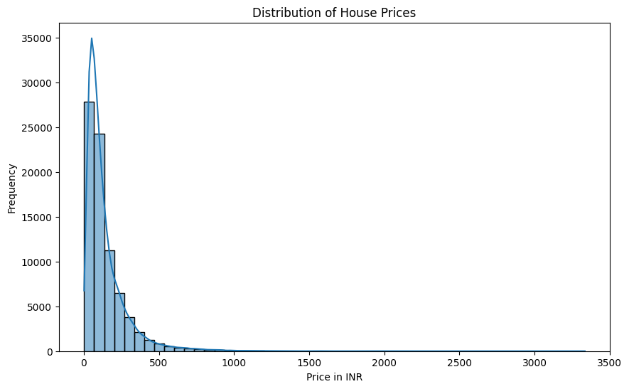

```python
# Lets Analyze our target variable:

# Histplot

import matplotlib.pyplot as plt
import seaborn as sns


plt.figure(figsize=(10,6))
sns.histplot(df['Price_INR_Lakhs'], bins=50, kde=True)
plt.title("Distribution of House Prices")
plt.xlabel("Price in INR")
plt.ylabel("Frequency")
plt.show()
```

### Inference:

- Most house prices are in the lower range.
- There are likely some `high-price outliers`.

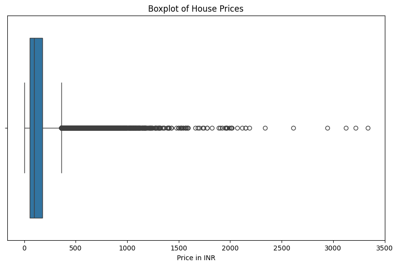

```python
# Boxplot

plt.figure(figsize=(10,6))

sns.boxplot(x=df['Price_INR_Lakhs'])

plt.title("Boxplot of House Prices")
plt.xlabel("Price in INR")
plt.show()
```

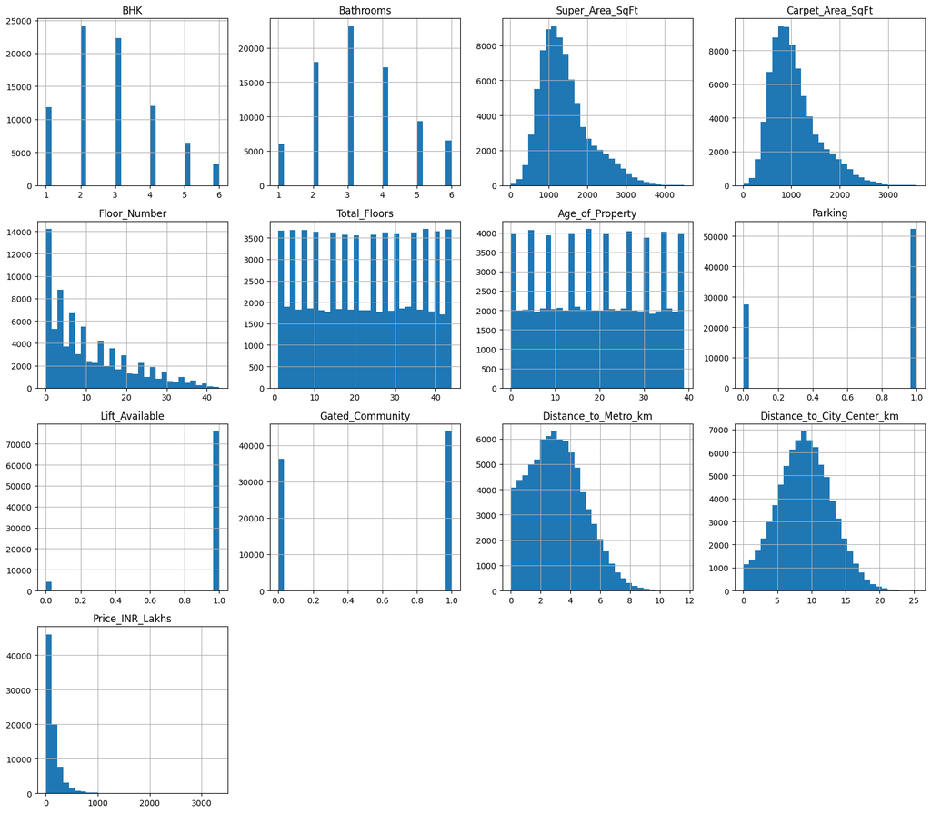

```python
# Numerical Feature Distribution:

numerical_cols = df.select_dtypes(include="number").columns

df[numerical_cols].hist(
    figsize=(16,14),
    bins=30
)

plt.tight_layout()
plt.show()
```

```python
# Categorical Column Distribution

categorical_cols = ["City", "Locality_Type", "Property_Type", "Furnishing_Status"]

for col in categorical_cols:
    print(f"\n{col}")
    print(df[col].value_counts())
```

```
City
City
Bangalore     8189
Chennai       8150
Hyderabad     8060
Delhi         8037
Mumbai        8024
Jaipur        8002
Ahmedabad     7982
Chandigarh    7873
Kolkata       7850
Pune          7833
Name: count, dtype: int64

Locality_Type
Locality_Type
Mid-Range     40243
Affordable    19972
Premium       19785
Name: count, dtype: int64

Property_Type
Property_Type
Apartment            20049
Villa                20031
Builder Floor        20022
Independent House    19898
Name: count, dtype: int64

Furnishing_Status
Furnishing_Status
Semi-Furnished    26801
Furnished         26783
Unfurnished       26416
Name: count, dtype: int64
```

### Bivariate EDA

- We ask the question: `Which features appear to be related to the target price ?`

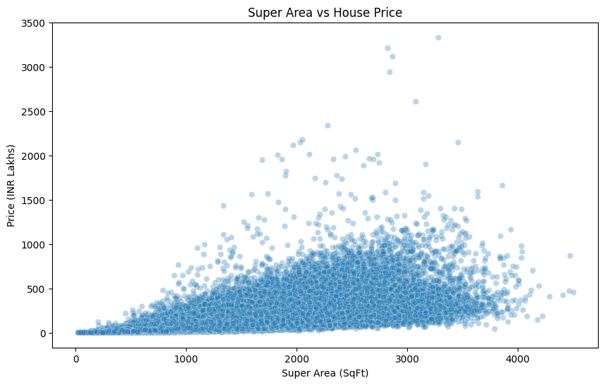

```python
# Super area vs Price

plt.figure(figsize=(10,6))

sns.scatterplot(
    data=df,
    x="Super_Area_SqFt",
    y="Price_INR_Lakhs",
    alpha=0.3
)

plt.title("Super Area vs House Price")
plt.xlabel("Super Area (SqFt)")
plt.ylabel("Price (INR Lakhs)")
plt.show()
```

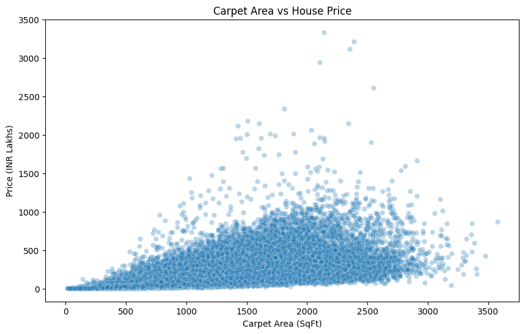

```python
# Carpet Area Vs Price

plt.figure(figsize=(10, 6))

sns.scatterplot(
    data=df,
    x="Carpet_Area_SqFt",
    y="Price_INR_Lakhs",
    alpha=0.3
)

plt.title("Carpet Area vs House Price")
plt.xlabel("Carpet Area (SqFt)")
plt.ylabel("Price (INR Lakhs)")
plt.show()
```

```python
df[["Super_Area_SqFt", "Carpet_Area_SqFt"]].corr()
```

|  | Super_Area_SqFt | Carpet_Area_SqFt |
| --- | --- | --- |
| Super_Area_SqFt | 1.000000 | 0.982889 |
| Carpet_Area_SqFt | 0.982889 | 1.000000 |

```python
corr = df.select_dtypes(include="number").corr()

corr["Price_INR_Lakhs"].sort_values(ascending=False)
```

```
Price_INR_Lakhs               1.000000
Super_Area_SqFt               0.635033
Carpet_Area_SqFt              0.623933
Parking                       0.013032
Gated_Community               0.009515
Distance_to_Metro_km          0.007584
Floor_Number                  0.002653
Lift_Available                0.002188
BHK                           0.002179
Bathrooms                     0.001643
Total_Floors                 -0.001476
Distance_to_City_Center_km   -0.090795
Age_of_Property              -0.107589
Name: Price_INR_Lakhs, dtype: float64
```

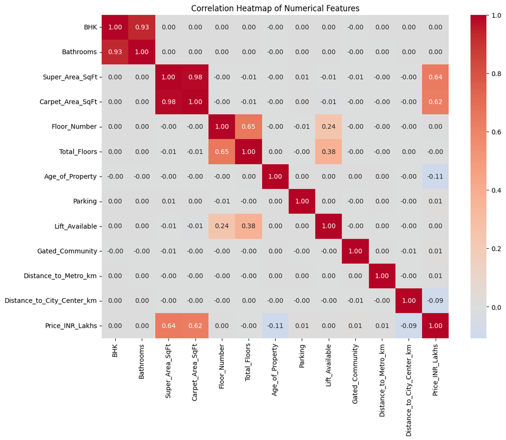

```python
plt.figure(figsize=(12, 9))

sns.heatmap(
    df.select_dtypes(include="number").corr(),
    annot=True,
    fmt=".2f",
    cmap="coolwarm",
    center=0
)

plt.title("Correlation Heatmap of Numerical Features")
plt.show()
```

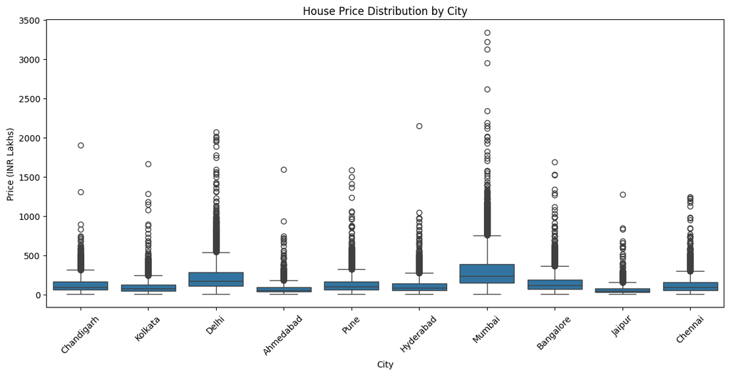

```python
plt.figure(figsize=(14, 6))

sns.boxplot(
    data=df,
    x="City",
    y="Price_INR_Lakhs"
)

plt.xticks(rotation=45)
plt.title("House Price Distribution by City")
plt.xlabel("City")
plt.ylabel("Price (INR Lakhs)")
plt.show()
```

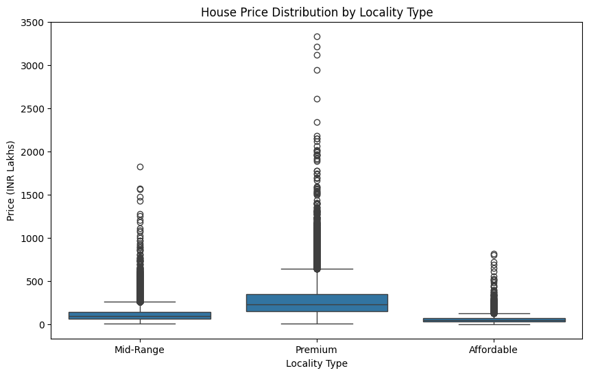

```python
plt.figure(figsize=(10, 6))

sns.boxplot(
    data=df,
    x="Locality_Type",
    y="Price_INR_Lakhs"
)

plt.title("House Price Distribution by Locality Type")
plt.xlabel("Locality Type")
plt.ylabel("Price (INR Lakhs)")
plt.show()
```

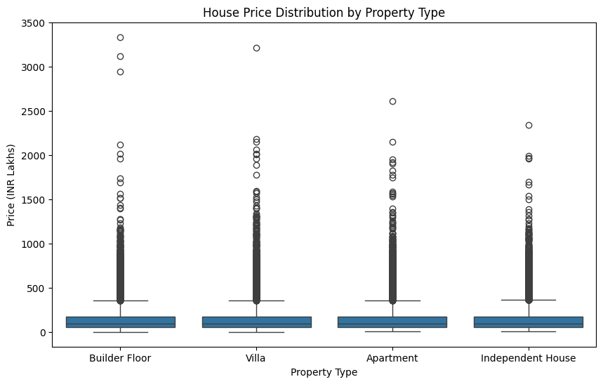

```python
plt.figure(figsize=(10, 6))

sns.boxplot(
    data=df,
    x="Property_Type",
    y="Price_INR_Lakhs"
)

plt.title("House Price Distribution by Property Type")
plt.xlabel("Property Type")
plt.ylabel("Price (INR Lakhs)")
plt.show()
```

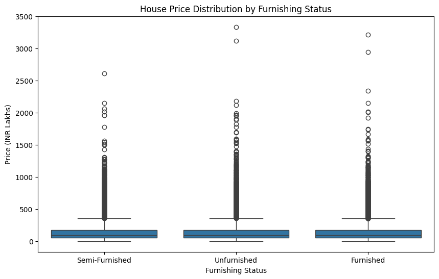

```python
plt.figure(figsize=(10, 6))

sns.boxplot(
    data=df,
    x="Furnishing_Status",
    y="Price_INR_Lakhs"
)

plt.title("House Price Distribution by Furnishing Status")
plt.xlabel("Furnishing Status")
plt.ylabel("Price (INR Lakhs)")
plt.show()
```

### ML Initialization

```python
df.shape
```

```
(80000, 18)
```

```python
df.head()
```

|  | Property_ID | City | Locality_Type | Property_Type | BHK | Bathrooms | Super_Area_SqFt | Carpet_Area_SqFt | Floor_Number | Total_Floors | Age_of_Property | Furnishing_Status | Parking | Lift_Available | Gated_Community | Distance_to_Metro_km | Distance_to_City_Center_km | Price_INR_Lakhs |
| --- | --- | --- | --- | --- | --- | --- | --- | --- | --- | --- | --- | --- | --- | --- | --- | --- | --- | --- |
| 0 | PROP-005003 | Chandigarh | Mid-Range | Builder Floor | 4 | 5 | 1293.82 | 862.81 | 21 | 36 | 11 | Semi-Furnished | 1 | 1 | 1 | 5.34 | 10.84 | 127.38 |
| 1 | PROP-009920 | Kolkata | Premium | Builder Floor | 2 | 2 | 2438.03 | 1977.23 | 16 | 31 | 16 | Semi-Furnished | 1 | 1 | 1 | 3.48 | 8.69 | 214.61 |
| 2 | PROP-003987 | Delhi | Mid-Range | Villa | 3 | 4 | 1065.54 | 721.68 | 2 | 3 | 32 | Semi-Furnished | 0 | 0 | 1 | 2.66 | 5.73 | 162.56 |
| 3 | PROP-084186 | Chandigarh | Mid-Range | Apartment | 1 | 2 | 1611.76 | 1327.15 | 38 | 41 | 27 | Semi-Furnished | 1 | 1 | 0 | 1.33 | 10.70 | 124.88 |
| 4 | PROP-068764 | Ahmedabad | Premium | Independent House | 5 | 5 | 1043.93 | 781.81 | 21 | 30 | 23 | Unfurnished | 0 | 1 | 0 | 1.75 | 7.22 | 94.77 |

```python
# Dropping the id columns as its of no use

df = df.drop(columns=['Property_ID'])
```

```python
df.head()
```

|  | City | Locality_Type | Property_Type | BHK | Bathrooms | Super_Area_SqFt | Carpet_Area_SqFt | Floor_Number | Total_Floors | Age_of_Property | Furnishing_Status | Parking | Lift_Available | Gated_Community | Distance_to_Metro_km | Distance_to_City_Center_km | Price_INR_Lakhs |
| --- | --- | --- | --- | --- | --- | --- | --- | --- | --- | --- | --- | --- | --- | --- | --- | --- | --- |
| 0 | Chandigarh | Mid-Range | Builder Floor | 4 | 5 | 1293.82 | 862.81 | 21 | 36 | 11 | Semi-Furnished | 1 | 1 | 1 | 5.34 | 10.84 | 127.38 |
| 1 | Kolkata | Premium | Builder Floor | 2 | 2 | 2438.03 | 1977.23 | 16 | 31 | 16 | Semi-Furnished | 1 | 1 | 1 | 3.48 | 8.69 | 214.61 |
| 2 | Delhi | Mid-Range | Villa | 3 | 4 | 1065.54 | 721.68 | 2 | 3 | 32 | Semi-Furnished | 0 | 0 | 1 | 2.66 | 5.73 | 162.56 |
| 3 | Chandigarh | Mid-Range | Apartment | 1 | 2 | 1611.76 | 1327.15 | 38 | 41 | 27 | Semi-Furnished | 1 | 1 | 0 | 1.33 | 10.70 | 124.88 |
| 4 | Ahmedabad | Premium | Independent House | 5 | 5 | 1043.93 | 781.81 | 21 | 30 | 23 | Unfurnished | 0 | 1 | 0 | 1.75 | 7.22 | 94.77 |

```python
# Seperating the Variables and the target:

X = df.drop(columns=['Price_INR_Lakhs'])
y = df['Price_INR_Lakhs']
```

```python
X.head()
```

|  | City | Locality_Type | Property_Type | BHK | Bathrooms | Super_Area_SqFt | Carpet_Area_SqFt | Floor_Number | Total_Floors | Age_of_Property | Furnishing_Status | Parking | Lift_Available | Gated_Community | Distance_to_Metro_km | Distance_to_City_Center_km |
| --- | --- | --- | --- | --- | --- | --- | --- | --- | --- | --- | --- | --- | --- | --- | --- | --- |
| 0 | Chandigarh | Mid-Range | Builder Floor | 4 | 5 | 1293.82 | 862.81 | 21 | 36 | 11 | Semi-Furnished | 1 | 1 | 1 | 5.34 | 10.84 |
| 1 | Kolkata | Premium | Builder Floor | 2 | 2 | 2438.03 | 1977.23 | 16 | 31 | 16 | Semi-Furnished | 1 | 1 | 1 | 3.48 | 8.69 |
| 2 | Delhi | Mid-Range | Villa | 3 | 4 | 1065.54 | 721.68 | 2 | 3 | 32 | Semi-Furnished | 0 | 0 | 1 | 2.66 | 5.73 |
| 3 | Chandigarh | Mid-Range | Apartment | 1 | 2 | 1611.76 | 1327.15 | 38 | 41 | 27 | Semi-Furnished | 1 | 1 | 0 | 1.33 | 10.70 |
| 4 | Ahmedabad | Premium | Independent House | 5 | 5 | 1043.93 | 781.81 | 21 | 30 | 23 | Unfurnished | 0 | 1 | 0 | 1.75 | 7.22 |

```python
y.head(10)
```

```
0    127.38
1    214.61
2    162.56
3    124.88
4     94.77
5    215.52
6    193.84
7     29.45
8     72.16
9     87.30
Name: Price_INR_Lakhs, dtype: float64
```

```python
# Performing the splitting

from sklearn.model_selection import train_test_split

X_train, X_temp, y_train, y_temp = train_test_split(
    X,
    y,
    test_size=0.3,
    random_state=42,

)

# Validation vs Test

X_val, X_test, y_val, y_test = train_test_split(
    X_temp,
    y_temp,
    test_size=0.50,
    random_state=42
)
```

```python
print(X_test.shape, X_val.shape, X_train.shape)
```

```
(12000, 16) (12000, 16) (56000, 16)
```

```python
# Seperating the feature types:

categorical_features = [
    "City",
    "Locality_Type",
    "Property_Type",
    "Furnishing_Status"
]

binary_features = [
    "Parking",
    "Lift_Available",
    "Gated_Community"
]

numerical_features = [
    "BHK",
    "Bathrooms",
    "Super_Area_SqFt",
    "Carpet_Area_SqFt",
    "Floor_Number",
    "Total_Floors",
    "Age_of_Property",
    "Distance_to_Metro_km",
    "Distance_to_City_Center_km"
]
```

```python
# Now we build the preprocessing pipelines for these groups seperately

from sklearn.compose import ColumnTransformer
from sklearn.preprocessing import OneHotEncoder, StandardScaler


preprocessor = ColumnTransformer(
    transformers = [
        (
            "num",
            StandardScaler(), # We using this as this scales on z scale and PCA looks at variance
            numerical_features
        ),
        (
            "cat",
            OneHotEncoder(handle_unknown="ignore", sparse_output=False),
            categorical_features
        ),
        (
            "bin",
            "passthrough",
            binary_features
        )
    ]
)
```

```python
# Lets see what will be the results like

X_train_processed = preprocessor.fit_transform(X_train)

X_val_processed = preprocessor.transform(X_val)

print("Original features:", X_train.shape[1])
print("Processed features:", X_train_processed.shape[1])
```

```
Original features: 16
Processed features: 32
```

```python
# Creating a PCA pipeline to check if PCA actually helps us or not.

from sklearn.decomposition import PCA
from sklearn.pipeline import Pipeline

pca_pipeline = Pipeline([
    ('preprocessor', preprocessor),
    ('pca', PCA(n_components=0.95))
])
```

```python
# Fitting the pipeline on the training data

X_train_pca = pca_pipeline.fit_transform(X_train, y_train)
```

```python
print("Original features:", X_train.shape[1])
print("Features after preprocessing:", X_train_processed.shape[1])
print("Features after PCA:", X_train_pca.shape[1])
```

```
Original features: 16
Features after preprocessing: 32
Features after PCA: 20
```

```python
# Lets create a baseline model first

from sklearn.dummy import DummyRegressor
from sklearn.metrics import mean_absolute_error, mean_squared_error, r2_score
import numpy as np

baseline = DummyRegressor(strategy='mean')

baseline.fit(X_train, y_train)
```

```
DummyRegressor()
```

```python
baseline_y_pred = baseline.predict(X_val)

mae = mean_absolute_error(y_val, baseline_y_pred)
mse = mean_squared_error(y_val, baseline_y_pred)
r2 = r2_score(y_val, baseline_y_pred)

print("BASELINE MODEL RESULTS:")
print("MAE:", mae)
print("MSE:", mse)
print("R2:", r2)
```

```
BASELINE MODEL RESULTS:
MAE: 95.53336043427504
MSE: 22348.012245397396
R2: -5.920110376611554e-05
```

### The models we will be testing are:

1. Linear Regression.
2. Ridge Regression
3. Lasso Regression
4. Random Forest
5. Gradient Boosting
6. XG Boosting.
7. Support Vector Machines
8. KNN

### LINEAR REGRESSION

```python
# Lets first do LR without PCA

from sklearn.linear_model import LinearRegression
from  sklearn.model_selection import cross_validate

lr = Pipeline([
    ("preprocessor", preprocessor),
    ("model", LinearRegression())
])

lr_cv = cross_validate(
    estimator=lr,
    X=X_train,
    y=y_train,
    cv=3,
    scoring={
        'MAE': 'neg_mean_absolute_error',
        "RMSE": 'neg_root_mean_squared_error',
        "MSE": 'neg_mean_squared_error',
        "R2": 'r2'
    },
    n_jobs=-1,
    verbose=3
)
```

```
[Parallel(n_jobs=-1)]: Using backend LokyBackend with 12 concurrent workers.
[Parallel(n_jobs=-1)]: Done   3 out of   3 | elapsed:    2.4s finished
```

```python
lr_cv
```

```
{'fit_time': array([0.11564207, 0.11862826, 0.11637497]),
 'score_time': array([0.03542328, 0.02774954, 0.03091455]),
 'test_MAE': array([-47.58001285, -47.93704047, -47.93392598]),
 'test_RMSE': array([-80.86691337, -84.43800056, -84.39599927]),
 'test_MSE': array([-6539.45767719, -7129.77593912, -7122.684692  ]),
 'test_R2': array([0.68457641, 0.67226752, 0.67078024])}
```

```python
lr_cv_results = pd.DataFrame([{
   "Model": "Linear Regression",
   "MAE": abs(lr_cv['test_MAE'].mean()),
   "MSE": abs(lr_cv['test_MSE'].mean()),
   "RMSE": abs(lr_cv['test_RMSE'].mean()),
   "R2": abs(lr_cv['test_R2'].mean()),
}])
```

```python
results_cv = pd.DataFrame(columns=['Model', 'MAE', 'MSE', 'RMSE', 'R2'])
```

```python
results = pd.concat([results_cv, lr_cv_results])
results
```

|  | Model | MAE | MSE | RMSE | R2 |
| --- | --- | --- | --- | --- | --- |
| 0 | Linear Regression | 47.816993 | 6930.639436 | 83.233638 | 0.675875 |

```python
# Linear Regression With PCA

lr_pca = Pipeline([
    ('pca_pipeline', pca_pipeline),
    ("model", LinearRegression())
])

lr_pca_cv = cross_validate(
    estimator=lr_pca,
    X=X_train,
    y=y_train,
    cv=3,
    scoring={
        'MAE': 'neg_mean_absolute_error',
        'MSE': 'neg_mean_squared_error',
        'RMSE': 'neg_root_mean_squared_error',
        'R2': 'r2'
    },
    n_jobs=-1,
    verbose=3
)
```

```
[Parallel(n_jobs=-1)]: Using backend LokyBackend with 12 concurrent workers.
```

```
[Parallel(n_jobs=-1)]: Done   3 out of   3 | elapsed:    2.0s finished
```

```python
lr_pca_cv_results = pd.DataFrame([{
    "Model": 'Linear Regression With PCA',
    'MAE': abs(lr_pca_cv['test_MAE'].mean()),
    'MSE': abs(lr_pca_cv['test_MSE'].mean()),
    'RMSE': abs(lr_pca_cv['test_RMSE'].mean()),
    'R2': abs(lr_pca_cv['test_R2'].mean()),
}])

lr_pca_cv_results
```

|  | Model | MAE | MSE | RMSE | R2 |
| --- | --- | --- | --- | --- | --- |
| 0 | Linear Regression With PCA | 53.19795 | 7830.66231 | 88.444901 | 0.633945 |

```python
results = pd.concat([results, lr_pca_cv_results], ignore_index=True)
results
```

|  | Model | MAE | MSE | RMSE | R2 |
| --- | --- | --- | --- | --- | --- |
| 0 | Linear Regression | 47.816993 | 6930.639436 | 83.233638 | 0.675875 |
| 1 | Linear Regression With PCA | 53.197950 | 7830.662310 | 88.444901 | 0.633945 |

### PCA made the Linear Regression Model worse. PCA is majorly used for unsupervised learning problem application and in this it failed to understand the importance of our target feature.

### Ridge Regression

```python
from sklearn.linear_model import Ridge
```

```python
r = Pipeline([
    ("preprocessor", preprocessor),
    ("model", Ridge(
        alpha=1.0
    ))
])

r_cv = cross_validate(
    estimator=r,
    X=X_train,
    y=y_train,
    cv=3,
    scoring={
        'MAE': 'neg_mean_absolute_error',
        'MSE': 'neg_mean_squared_error',
        'RMSE': 'neg_root_mean_squared_error',
        'R2': 'r2'
    },
    n_jobs=-1,
    verbose=3
)
```

```
[Parallel(n_jobs=-1)]: Using backend LokyBackend with 12 concurrent workers.
[Parallel(n_jobs=-1)]: Done   3 out of   3 | elapsed:    1.9s finished
```

```python
def get_results(model_name, cross_validation_result):
    result = pd.DataFrame([{
        "Model": model_name,
        "MAE": abs(cross_validation_result['test_MAE'].mean()),
        "MSE": abs(cross_validation_result['test_MSE'].mean()),
        "RMSE": abs(cross_validation_result['test_RMSE'].mean()),
        "R2": abs(cross_validation_result['test_R2'].mean()),
    }])

    return result
```

```python
r_results = get_results("Ridge Regression", r_cv)
r_results
```

|  | Model | MAE | MSE | RMSE | R2 |
| --- | --- | --- | --- | --- | --- |
| 0 | Ridge Regression | 47.813296 | 6930.636981 | 83.23362 | 0.675875 |

```python
def results_merger(overall_results=None, new_results=None):

    model_name = new_results['Model'].iloc[0]

    if model_name not in overall_results['Model'].values:
        results = pd.concat([overall_results, new_results], ignore_index=True)
    else:
        print("Model Already exists.")
        results = overall_results

    return results
```

```python
results = results_merger(results, r_results)
results
```

|  | Model | MAE | MSE | RMSE | R2 |
| --- | --- | --- | --- | --- | --- |
| 0 | Linear Regression | 47.816993 | 6930.639436 | 83.233638 | 0.675875 |
| 1 | Linear Regression With PCA | 53.197950 | 7830.662310 | 88.444901 | 0.633945 |
| 2 | Ridge Regression | 47.813296 | 6930.636981 | 83.233620 | 0.675875 |

### LASSO REGRESSION

```python
from sklearn.linear_model import Lasso
```

```python
lasso = Pipeline([
    ('preprocessor', preprocessor),
    ('model', Lasso(
        alpha=1.0
    ))
])
```

```python
lasso_cv = cross_validate(
    estimator=lasso,
    X=X_train,
    y=y_train,
    cv=3,
    scoring={
        'MAE': 'neg_mean_absolute_error',
        'MSE': 'neg_mean_squared_error',
        'RMSE': 'neg_root_mean_squared_error',
        'R2': 'r2'
    },
    n_jobs=-1,
    verbose=3
)
```

```
[Parallel(n_jobs=-1)]: Using backend LokyBackend with 12 concurrent workers.
[Parallel(n_jobs=-1)]: Done   3 out of   3 | elapsed:    1.9s finished
```

```python
lasso_cv_results = get_results("Lasso Regression", lasso_cv)
lasso_cv_results
```

|  | Model | MAE | MSE | RMSE | R2 |
| --- | --- | --- | --- | --- | --- |
| 0 | Lasso Regression | 46.803567 | 7023.229326 | 83.787077 | 0.671551 |

```python
results = results_merger(results, lasso_cv_results)
results
```

|  | Model | MAE | MSE | RMSE | R2 |
| --- | --- | --- | --- | --- | --- |
| 0 | Linear Regression | 47.816993 | 6930.639436 | 83.233638 | 0.675875 |
| 1 | Linear Regression With PCA | 53.197950 | 7830.662310 | 88.444901 | 0.633945 |
| 2 | Ridge Regression | 47.813296 | 6930.636981 | 83.233620 | 0.675875 |
| 3 | Lasso Regression | 46.803567 | 7023.229326 | 83.787077 | 0.671551 |

### RANDOM FOREST

```python
from sklearn.ensemble import RandomForestRegressor
```

```python
rf_pipeline = Pipeline([
    ('preprocessor', preprocessor),
    ('model', RandomForestRegressor(
        n_estimators=100,
        max_depth=3,
        min_samples_split=2,
        min_samples_leaf=2
    ))
])


rf_cv = cross_validate(
    estimator=rf_pipeline,
    X=X_train,
    y=y_train,
    cv=3,
    scoring={
        "MAE": 'neg_mean_absolute_error',
        "MSE": 'neg_mean_squared_error',
        "RMSE": 'neg_root_mean_squared_error',
        "R2": "r2"
    },
    n_jobs=-1,
    verbose=3
)
```

```
[Parallel(n_jobs=-1)]: Using backend LokyBackend with 12 concurrent workers.
```

```
[Parallel(n_jobs=-1)]: Done   3 out of   3 | elapsed:    6.2s finished
```

```python
rf_results = get_results("Random Forest Regressor", rf_cv)
rf_results
```

|  | Model | MAE | MSE | RMSE | R2 |
| --- | --- | --- | --- | --- | --- |
| 0 | Random Forest Regressor | 52.416082 | 7585.115395 | 87.052631 | 0.645389 |

```python
results = results_merger(results, rf_results)
results
```

|  | Model | MAE | MSE | RMSE | R2 |
| --- | --- | --- | --- | --- | --- |
| 0 | Linear Regression | 47.816993 | 6930.639436 | 83.233638 | 0.675875 |
| 1 | Linear Regression With PCA | 53.197950 | 7830.662310 | 88.444901 | 0.633945 |
| 2 | Ridge Regression | 47.813296 | 6930.636981 | 83.233620 | 0.675875 |
| 3 | Lasso Regression | 46.803567 | 7023.229326 | 83.787077 | 0.671551 |
| 4 | Random Forest Regressor | 52.416082 | 7585.115395 | 87.052631 | 0.645389 |

### Gradient Boosting

```python
from sklearn.ensemble import GradientBoostingRegressor
```

```python
gbr = Pipeline([
    ("preprocessor", preprocessor),
    ('model', GradientBoostingRegressor(
        random_state=42
    ))
])

gbr_cv = cross_validate(
    estimator=gbr,
    X=X_train,
    y=y_train,
    cv=3,
    scoring={
        "MAE": 'neg_mean_absolute_error',
        "MSE": 'neg_mean_squared_error',
        "RMSE": 'neg_root_mean_squared_error',
        "R2": 'r2'
    },
    n_jobs=-1,
    verbose=3
)
```

```
[Parallel(n_jobs=-1)]: Using backend LokyBackend with 12 concurrent workers.
```

```
[Parallel(n_jobs=-1)]: Done   3 out of   3 | elapsed:    9.7s finished
```

```python
gbr_results = get_results("Gradient Boosting", gbr_cv)
gbr_results
```

|  | Model | MAE | MSE | RMSE | R2 |
| --- | --- | --- | --- | --- | --- |
| 0 | Gradient Boosting | 34.094898 | 4602.689191 | 67.816677 | 0.784815 |

```python
results = results_merger(results, gbr_results)
results
```

|  | Model | MAE | MSE | RMSE | R2 |
| --- | --- | --- | --- | --- | --- |
| 0 | Linear Regression | 47.816993 | 6930.639436 | 83.233638 | 0.675875 |
| 1 | Linear Regression With PCA | 53.197950 | 7830.662310 | 88.444901 | 0.633945 |
| 2 | Ridge Regression | 47.813296 | 6930.636981 | 83.233620 | 0.675875 |
| 3 | Lasso Regression | 46.803567 | 7023.229326 | 83.787077 | 0.671551 |
| 4 | Random Forest Regressor | 52.416082 | 7585.115395 | 87.052631 | 0.645389 |
| 5 | Gradient Boosting | 34.094898 | 4602.689191 | 67.816677 | 0.784815 |

### XG Boosting

```python
!pip install xgboost --quiet
```

```python
from xgboost import XGBRegressor
```

```python
xgb = Pipeline([
    ("preprocessor", preprocessor),
    ("model", XGBRegressor(
        random_state=42
    ))
])
```

```python
xgb_cv = cross_validate(
    estimator=xgb,
    X=X_train,
    y=y_train,
    cv=3,
    scoring={
        'MAE': 'neg_mean_absolute_error',
        'MSE': 'neg_mean_squared_error',
        'RMSE': 'neg_root_mean_squared_error',
        'R2': 'r2'
    },
    n_jobs=-1,
    verbose=3
)
```

```
[Parallel(n_jobs=-1)]: Using backend LokyBackend with 12 concurrent workers.
[Parallel(n_jobs=-1)]: Done   3 out of   3 | elapsed:    0.5s finished
```

```python
xgb_results = get_results("XGBoost", xgb_cv)
xgb_results
```

|  | Model | MAE | MSE | RMSE | R2 |
| --- | --- | --- | --- | --- | --- |
| 0 | XGBoost | 35.163867 | 5042.509854 | 70.999502 | 0.76415 |

```python
results = results_merger(results, xgb_results)
results
```

|  | Model | MAE | MSE | RMSE | R2 |
| --- | --- | --- | --- | --- | --- |
| 0 | Linear Regression | 47.816993 | 6930.639436 | 83.233638 | 0.675875 |
| 1 | Linear Regression With PCA | 53.197950 | 7830.662310 | 88.444901 | 0.633945 |
| 2 | Ridge Regression | 47.813296 | 6930.636981 | 83.233620 | 0.675875 |
| 3 | Lasso Regression | 46.803567 | 7023.229326 | 83.787077 | 0.671551 |
| 4 | Random Forest Regressor | 52.416082 | 7585.115395 | 87.052631 | 0.645389 |
| 5 | Gradient Boosting | 34.094898 | 4602.689191 | 67.816677 | 0.784815 |
| 6 | XGBoost | 35.163867 | 5042.509854 | 70.999502 | 0.764150 |